# Examining background gene lists in clusterProfiler - RNA-seq example

Mark Ziemann & Anusuiya Bora

2024-06-06

Source: https://github.com/markziemann/background

## Introduction

This guide is a Rmarkdown script that conducts differential expression and enrichment analysis, which are very popular workflows for transcriptome data.

The goal of this work is to understand the behaviour of ClusterProfiler’s p-value adjustment method as we have observed some weird behaviour. In particular we see that clusterprofiler’s criteria for inclusion/exclusion of gene sets is irregular. For example clusterprofiler seems to include gene sets as detected if there is just 1 member detected in the foreground list. If a gene set has 10 in the background and 0 in the foreground it looks like it gets excluded. This is a bit strange and contrary to best practice, where the detection threshold should be set by the overlap size in the background list, rather than the foreground list.

Theoretically, this behaviour could have a negative impact on performance, as FDR is applied to the wrong pathways.

```r
suppressPackageStartupMessages({
  library("getDEE2")
  library("DESeq2")
  library("kableExtra")
  library("clusterProfiler")
  library("fgsea")
  library("eulerr")
  library("gplots")
  library("parallel")
})
```

For this guide I will be using bulk RNA-seq data from several previous studies.

## Load data

Gene sets were obtained from MSigDB.

```r
myfiles <- list.files("../dataprep",pattern="*Rds",full.names=TRUE)
d <- lapply(myfiles,readRDS)
names(d) <- basename(myfiles)

mygmts <- list.files("../gmt",pattern="*gmt",full.names=TRUE)
gs <- lapply(mygmts,gmtPathways)
names(gs) <- basename(mygmts)

names(gs)
```

```
## [1] "c2.cp.kegg_medicus.v2023.2.Hs.symbols.gmt"
## [2] "c2.cp.reactome.v2023.2.Hs.symbols.gmt"
## [3] "c2.cp.wikipathways.v2023.2.Hs.symbols.gmt"
## [4] "c3.mir.mirdb.v2023.2.Hs.symbols.gmt"
## [5] "c3.tft.gtrd.v2023.2.Hs.symbols.gmt"
## [6] "c5.go.v2023.2.Hs.symbols.gmt"
## [7] "c5.hpo.v2023.2.Hs.symbols.gmt"
## [8] "c8.all.v2023.2.Hs.symbols.gmt"
## [9] "h.all.v2023.2.Hs.symbols.gmt"
```

```r
names(gs) <- c("KEGG", "Reactome", "Wikipathways", "miR targets", "TFT GTRD",
  "GO", "HPO", "Cellmarkers", "Hallmark" )
```

## Basic geneset analysis

```r
# number of sets
lapply(gs,length)
```

```
## $KEGG
## [1] 619
##
## $Reactome
## [1] 1692
##
## $Wikipathways
## [1] 791
##
## $`miR targets`
## [1] 2377
##
## $`TFT GTRD`
## [1] 505
##
## $GO
## [1] 10461
##
## $HPO
## [1] 5547
##
## $Cellmarkers
## [1] 830
##
## $Hallmark
## [1] 50
```

```r
# set size summary
lapply(gs,function(x) {
  y <- unlist(lapply(x, length ))
  summary(y)
} )
```

```
## $KEGG
##    Min. 1st Qu.  Median    Mean 3rd Qu.    Max.
##    5.00    8.00   13.00   15.59   19.00   92.00
##
## $Reactome
##    Min. 1st Qu.  Median    Mean 3rd Qu.    Max.
##    5.00   11.00   23.00   56.28   57.00 1463.00
##
## $Wikipathways
##    Min. 1st Qu.  Median    Mean 3rd Qu.    Max.
##    5.00   14.00   28.00   42.92   53.00  438.00
##
## $`miR targets`
##    Min. 1st Qu.  Median    Mean 3rd Qu.    Max.
##     5.0    59.0   103.0   156.5   186.0  1071.0
##
## $`TFT GTRD`
##    Min. 1st Qu.  Median    Mean 3rd Qu.    Max.
##     5.0    55.0   287.0   509.3   880.0  1999.0
##
## $GO
##    Min. 1st Qu.  Median    Mean 3rd Qu.    Max.
##    5.00    9.00   18.00   79.83   55.00 1994.00
##
## $HPO
##    Min. 1st Qu.  Median    Mean 3rd Qu.    Max.
##    5.00   10.00   23.00   91.32   74.00 1735.00
##
## $Cellmarkers
##    Min. 1st Qu.  Median    Mean 3rd Qu.    Max.
##     5.0    52.0   115.0   180.5   223.2  1770.0
##
## $Hallmark
##    Min. 1st Qu.  Median    Mean 3rd Qu.    Max.
##    32.0    98.0   180.0   146.4   200.0   200.0
```

```r
# gene coverage
lapply(gs,function(x) {
  y <- unique(unlist(x))
  length(y)
} )
```

```
## $KEGG
## [1] 2727
##
## $Reactome
## [1] 11155
##
## $Wikipathways
## [1] 8313
##
## $`miR targets`
## [1] 16655
##
## $`TFT GTRD`
## [1] 26807
##
## $GO
## [1] 19428
##
## $HPO
## [1] 4997
##
## $Cellmarkers
## [1] 20418
##
## $Hallmark
## [1] 4384
```

```r
# total number of annotations
lapply(gs, function(x) {
  sum(unlist(lapply(x,length)))
} )
```

```
## $KEGG
## [1] 9651
##
## $Reactome
## [1] 95226
##
## $Wikipathways
## [1] 33947
##
## $`miR targets`
## [1] 372061
##
## $`TFT GTRD`
## [1] 257181
##
## $GO
## [1] 835146
##
## $HPO
## [1] 506552
##
## $Cellmarkers
## [1] 149827
##
## $Hallmark
## [1] 7322
```

## Enrichment with Clusterprofiler

Here is a function that conducts over-representation analysis with ClusterProfiler. Genes that are not annotated as having any gene set category are discarded.

```r
# df = deseq output
# df must have "ensID geneSymbol" as rownames

# gs = gene sets
# gs format is list of symbols
orabad <- function( df, gs, ngenes=2000 ) {

  def <- df

  gs1 <- stack(gs)
  colnames(gs1) <- c("gene","term")
  gs1 <- gs1[,c(2,1)]

  defup <- head(rownames(subset(def,log2FoldChange>0)),ngenes)
  defup <- defup[lapply(strsplit(defup," "),length)==2]
  defup <- unique(sapply(strsplit(defup," "),"[[",2))

  defdn <- head(rownames(subset(def,log2FoldChange<0)),ngenes)
  defdn <- defdn[lapply(strsplit(defdn," "),length)==2]
  defdn <- unique(sapply(strsplit(defdn," "),"[[",2))

  bg <- rownames(def)
  bg <- bg[lapply(strsplit(bg," "),length)==2]
  bg <- unique(sapply(strsplit(bg," "),"[[",2))

  ora_up <- as.data.frame(enricher(gene = defup ,
    universe = bg, minGSSize = 5, maxGSSize = 500000, TERM2GENE = gs1,
    pAdjustMethod="fdr",  pvalueCutoff = 1, qvalueCutoff = 1  ))

  ora_up$geneID <- NULL
  ora_ups <- rownames(ora_up)

  gr <- as.numeric(sapply(strsplit(ora_up$GeneRatio,"/"),"[[",1)) /
    as.numeric(sapply(strsplit(ora_up$GeneRatio,"/"),"[[",2))

  br <- as.numeric(sapply(strsplit(ora_up$BgRatio,"/"),"[[",1)) /
    as.numeric(sapply(strsplit(ora_up$BgRatio,"/"),"[[",2))

  ora_up$es <- gr/br
  ora_up <- ora_up[order(-ora_up$es),]
  ora_up$Description=NULL

  ora_dn <- as.data.frame(enricher(gene = defdn ,
    universe = bg, minGSSize = 5, maxGSSize = 500000, TERM2GENE = gs1,
    pAdjustMethod="fdr",  pvalueCutoff = 1, qvalueCutoff = 1  ))

  ora_dn$geneID <- NULL
  ora_dns <- rownames(ora_dn)

  gr <- as.numeric(sapply(strsplit(ora_dn$GeneRatio,"/"),"[[",1)) /
    as.numeric(sapply(strsplit(ora_dn$GeneRatio,"/"),"[[",2))

  br <- as.numeric(sapply(strsplit(ora_dn$BgRatio,"/"),"[[",1)) /
    as.numeric(sapply(strsplit(ora_dn$BgRatio,"/"),"[[",2))

  ora_dn$es <- gr/br
  ora_dn <- ora_dn[order(-ora_dn$es),]
  ora_dn$Description=NULL

  result <- list("orabad_up"=ora_up,"orabad_dn"=ora_dn)
  return(result)
}
```

This function fixes the problem with not inlcuding sets for FDR correction.

```r
oragood <- function( df, gs, ngenes=2000 ) {

  def <- df

  gs1 <- stack(gs)
  colnames(gs1) <- c("gene","term")
  gs1 <- gs1[,c(2,1)]

  defup <- head(rownames(subset(def,log2FoldChange>0)),ngenes)
  defup <- defup[lapply(strsplit(defup," "),length)==2]
  defup <- unique(sapply(strsplit(defup," "),"[[",2))

  defdn <- head(rownames(subset(def,log2FoldChange<0)),ngenes)
  defdn <- defdn[lapply(strsplit(defdn," "),length)==2]
  defdn <- unique(sapply(strsplit(defdn," "),"[[",2))

  bg <- rownames(def)
  bg <- bg[lapply(strsplit(bg," "),length)==2]
  bg <- unique(sapply(strsplit(bg," "),"[[",2))

  gs1 <- gs1[which(gs1$gene %in% bg),]
  terms <- names(which(table(gs1$term)>5))
  gs1 <- gs1[gs1$term %in% terms,]

  ora_up <- as.data.frame(enricher(gene = defup ,
    universe = bg, minGSSize = 5, maxGSSize = 500000, TERM2GENE = gs1,
    pAdjustMethod="fdr",  pvalueCutoff = 1, qvalueCutoff = 1  ))

  ora_up$geneID <- NULL
  ora_ups <- rownames(ora_up)

  gr <- as.numeric(sapply(strsplit(ora_up$GeneRatio,"/"),"[[",1)) /
    as.numeric(sapply(strsplit(ora_up$GeneRatio,"/"),"[[",2))

  br <- as.numeric(sapply(strsplit(ora_up$BgRatio,"/"),"[[",1)) /
    as.numeric(sapply(strsplit(ora_up$BgRatio,"/"),"[[",2))

  ora_up$es <- gr/br
  ora_up <- ora_up[order(-ora_up$es),]
  ora_up$Description=NULL

  nsets <- length(which(table(gs1$term)>5))
  nres <- nrow(ora_up)
  diff <- nsets - nres
  pvals <- c(ora_up$pvalue,rep(1,diff))
  ora_up$p.adjust <- p.adjust(pvals,method="fdr")[1:nrow(ora_up)]

  ora_dn <- as.data.frame(enricher(gene = defdn ,
    universe = bg, minGSSize = 5, maxGSSize = 500000, TERM2GENE = gs1,
    pAdjustMethod="fdr",  pvalueCutoff = 1, qvalueCutoff = 1  ))

  ora_dn$geneID <- NULL
  ora_dns <- rownames(ora_dn)

  gr <- as.numeric(sapply(strsplit(ora_dn$GeneRatio,"/"),"[[",1)) /
    as.numeric(sapply(strsplit(ora_dn$GeneRatio,"/"),"[[",2))

  br <- as.numeric(sapply(strsplit(ora_dn$BgRatio,"/"),"[[",1)) /
    as.numeric(sapply(strsplit(ora_dn$BgRatio,"/"),"[[",2))

  ora_dn$es <- gr/br
  ora_dn <- ora_dn[order(-ora_dn$es),]
  ora_dn$Description=NULL

  nsets <- length(which(table(gs1$term)>5))
  nres <- nrow(ora_dn)
  diff <- nsets - nres
  pvals <- c(ora_dn$pvalue,rep(1,diff))
  ora_dn$p.adjust <- p.adjust(pvals,method="fdr")[1:nrow(ora_dn)]

  result <- list("oragood_up"=ora_up,"oragood_dn"=ora_dn)
  return(result)
}
```

## Compare the results of bad and good analysis

```r
# bad=ORA analysis, a list with results of up and down regulated pathways
# good=same as bad, except fixed the background problem
compare_ora_plots <- function(bad,good,libname=NULL,setsize=NULL){
  badup <- bad$orabad_up
  baddn <- bad$orabad_dn
  goodup <- good$oragood_up
  gooddn <- good$oragood_dn
  mup <- merge(badup,goodup,by=0)

  MAX=max(-log10(c(mup$p.adjust.x,mup$p.adjust.y)))
  UPHEADER=paste(libname,"up",setsize,"genes")
  DNHEADER=paste(libname,"dn",setsize,"genes")

  par(mfrow=c(1,2))

  plot(-log10(mup$p.adjust.x), -log10(mup$p.adjust.y),
    xlim=c(0,MAX), ylim=c(0,MAX),
    xlab="original -log10 FDR", ylab="corrected -log10 FDR", main=UPHEADER)
  grid()
  abline(a = 0, b = 1,lwd=2,lty=2)

  mdn <- merge(baddn,gooddn,by=0)

  MAX=max(-log10(c(mdn$p.adjust.x,mdn$p.adjust.y)))

  plot(-log10(mdn$p.adjust.x), -log10(mdn$p.adjust.y),
    xlim=c(0,MAX), ylim=c(0,MAX),
    xlab="original -log10 FDR", ylab="corrected -log10 FDR", main=DNHEADER)
  grid()
  abline(a = 0, b = 1,lwd=2,lty=2)
}

compare_ora <- function(bad,good){
  badup <- bad$orabad_up
  baddn <- bad$orabad_dn
  goodup <- good$oragood_up
  gooddn <- good$oragood_dn
  bup <- rownames(subset(badup,p.adjust<0.05))
  gup <- rownames(subset(goodup,p.adjust<0.05))
  bdn <- rownames(subset(baddn,p.adjust<0.05))
  gdn <- rownames(subset(gooddn,p.adjust<0.05))
  sig_bad <- unique(c(bup,bdn))
  sig_good <- unique(c(gup,gdn))
  nsig_bad <- length(sig_bad)
  nsig_good <- length(sig_good)
  jac <- length(intersect(sig_bad,sig_good)) / length(union(sig_bad,sig_good))
  result=c("nsig_bad"=nsig_bad,"nsig_good"=nsig_good,"Jaccard"=jac)
  return(result)
}
```

## Run some analyses

```r
params <- expand.grid(1:length(d),1:length(gs))
params2 <- expand.grid(names(d),names(gs))

colnames(params) <- c("d","gs")

ora_dat <- mclapply(1:nrow(params), function(i) {
  j=params[i,1]
  k=params[i,2]
  bad <- orabad(d[[j]],gs[[k]])
  good <- oragood(d[[j]],gs[[k]])
  res <- compare_ora(bad,good)
  return(res)
} , mc.cores=8)

ora_dat <- do.call(rbind,ora_dat)

res1 <- cbind(params2,ora_dat)

res1 %>%
  kbl(row.names = TRUE, caption="all results") %>%
  kable_paper("hover", full_width = F)
```

all results

|  | Var1 | Var2 | nsig_bad | nsig_good | Jaccard |
| --- | --- | --- | --- | --- | --- |
| 1 | bulkrna1.Rds | KEGG | 3 | 3 | 1.0000000 |
| 2 | bulkrna2.Rds | KEGG | 1 | 0 | 0.0000000 |
| 3 | bulkrna3.Rds | KEGG | 1 | 0 | 0.0000000 |
| 4 | bulkrna4.Rds | KEGG | 8 | 8 | 1.0000000 |
| 5 | bulkrna5.Rds | KEGG | 0 | 0 | NaN |
| 6 | bulkrna6.Rds | KEGG | 1 | 1 | 1.0000000 |
| 7 | bulkrna7.Rds | KEGG | 0 | 0 | NaN |
| 8 | bulkrna1.Rds | Reactome | 122 | 121 | 0.9918033 |
| 9 | bulkrna2.Rds | Reactome | 96 | 96 | 1.0000000 |
| 10 | bulkrna3.Rds | Reactome | 98 | 97 | 0.9897959 |
| 11 | bulkrna4.Rds | Reactome | 108 | 105 | 0.9722222 |
| 12 | bulkrna5.Rds | Reactome | 39 | 36 | 0.9230769 |
| 13 | bulkrna6.Rds | Reactome | 74 | 72 | 0.9729730 |
| 14 | bulkrna7.Rds | Reactome | 24 | 17 | 0.7083333 |
| 15 | bulkrna1.Rds | Wikipathways | 18 | 18 | 1.0000000 |
| 16 | bulkrna2.Rds | Wikipathways | 18 | 18 | 1.0000000 |
| 17 | bulkrna3.Rds | Wikipathways | 3 | 3 | 1.0000000 |
| 18 | bulkrna4.Rds | Wikipathways | 0 | 0 | NaN |
| 19 | bulkrna5.Rds | Wikipathways | 0 | 0 | NaN |
| 20 | bulkrna6.Rds | Wikipathways | 18 | 18 | 1.0000000 |
| 21 | bulkrna7.Rds | Wikipathways | 6 | 6 | 1.0000000 |
| 22 | bulkrna1.Rds | miR targets | 188 | 184 | 0.9787234 |
| 23 | bulkrna2.Rds | miR targets | 37 | 37 | 1.0000000 |
| 24 | bulkrna3.Rds | miR targets | 3 | 3 | 1.0000000 |
| 25 | bulkrna4.Rds | miR targets | 2 | 2 | 1.0000000 |
| 26 | bulkrna5.Rds | miR targets | 270 | 269 | 0.9962963 |
| 27 | bulkrna6.Rds | miR targets | 690 | 688 | 0.9971014 |
| 28 | bulkrna7.Rds | miR targets | 36 | 36 | 1.0000000 |
| 29 | bulkrna1.Rds | TFT GTRD | 88 | 88 | 1.0000000 |
| 30 | bulkrna2.Rds | TFT GTRD | 88 | 87 | 0.9886364 |
| 31 | bulkrna3.Rds | TFT GTRD | 100 | 96 | 0.9600000 |
| 32 | bulkrna4.Rds | TFT GTRD | 66 | 66 | 1.0000000 |
| 33 | bulkrna5.Rds | TFT GTRD | 113 | 111 | 0.9823009 |
| 34 | bulkrna6.Rds | TFT GTRD | 89 | 87 | 0.9775281 |
| 35 | bulkrna7.Rds | TFT GTRD | 64 | 62 | 0.9687500 |
| 36 | bulkrna1.Rds | GO | 289 | 289 | 1.0000000 |
| 37 | bulkrna2.Rds | GO | 621 | 600 | 0.9661836 |
| 38 | bulkrna3.Rds | GO | 269 | 262 | 0.9739777 |
| 39 | bulkrna4.Rds | GO | 88 | 82 | 0.9318182 |
| 40 | bulkrna5.Rds | GO | 214 | 205 | 0.9579439 |
| 41 | bulkrna6.Rds | GO | 188 | 177 | 0.9414894 |
| 42 | bulkrna7.Rds | GO | 323 | 313 | 0.9690402 |
| 43 | bulkrna1.Rds | HPO | 9 | 9 | 1.0000000 |
| 44 | bulkrna2.Rds | HPO | 2 | 2 | 1.0000000 |
| 45 | bulkrna3.Rds | HPO | 1 | 1 | 1.0000000 |
| 46 | bulkrna4.Rds | HPO | 0 | 0 | NaN |
| 47 | bulkrna5.Rds | HPO | 0 | 0 | NaN |
| 48 | bulkrna6.Rds | HPO | 0 | 0 | NaN |
| 49 | bulkrna7.Rds | HPO | 0 | 0 | NaN |
| 50 | bulkrna1.Rds | Cellmarkers | 82 | 81 | 0.9878049 |
| 51 | bulkrna2.Rds | Cellmarkers | 255 | 255 | 1.0000000 |
| 52 | bulkrna3.Rds | Cellmarkers | 91 | 91 | 1.0000000 |
| 53 | bulkrna4.Rds | Cellmarkers | 31 | 31 | 1.0000000 |
| 54 | bulkrna5.Rds | Cellmarkers | 43 | 43 | 1.0000000 |
| 55 | bulkrna6.Rds | Cellmarkers | 104 | 104 | 1.0000000 |
| 56 | bulkrna7.Rds | Cellmarkers | 240 | 242 | 0.9917355 |
| 57 | bulkrna1.Rds | Hallmark | 3 | 3 | 1.0000000 |
| 58 | bulkrna2.Rds | Hallmark | 13 | 13 | 1.0000000 |
| 59 | bulkrna3.Rds | Hallmark | 3 | 3 | 1.0000000 |
| 60 | bulkrna4.Rds | Hallmark | 2 | 2 | 1.0000000 |
| 61 | bulkrna5.Rds | Hallmark | 0 | 0 | NaN |
| 62 | bulkrna6.Rds | Hallmark | 12 | 12 | 1.0000000 |
| 63 | bulkrna7.Rds | Hallmark | 3 | 3 | 1.0000000 |

```r
summary(res1$nsig_bad)
```

```
##    Min. 1st Qu.  Median    Mean 3rd Qu.    Max.
##    0.00    2.50   31.00   85.05   99.00  690.00
```

```r
summary(res1$nsig_good)
```

```
##    Min. 1st Qu.  Median    Mean 3rd Qu.    Max.
##    0.00    2.50   31.00   83.46   96.50  688.00
```

```r
summary(res1$Jaccard)
```

```
##    Min. 1st Qu.  Median    Mean 3rd Qu.    Max.    NA's
##  0.0000  0.9749  1.0000  0.9468  1.0000  1.0000       9
```

```r
# NUMBER OF SIGNIFICANT SETS
ns1 <- matrix( res1$nsig_bad , ncol=9 )
rownames(ns1) <- names(d)
colnames(ns1) <- names(gs)

ns1 %>%
  kbl(row.names = TRUE, caption="significant genesets in original analysis") %>%
  kable_paper("hover", full_width = F)
```

significant genesets in original analysis

|  | KEGG | Reactome | Wikipathways | miR targets | TFT GTRD | GO | HPO | Cellmarkers | Hallmark |
| --- | --- | --- | --- | --- | --- | --- | --- | --- | --- |
| bulkrna1.Rds | 3 | 122 | 18 | 188 | 88 | 289 | 9 | 82 | 3 |
| bulkrna2.Rds | 1 | 96 | 18 | 37 | 88 | 621 | 2 | 255 | 13 |
| bulkrna3.Rds | 1 | 98 | 3 | 3 | 100 | 269 | 1 | 91 | 3 |
| bulkrna4.Rds | 8 | 108 | 0 | 2 | 66 | 88 | 0 | 31 | 2 |
| bulkrna5.Rds | 0 | 39 | 0 | 270 | 113 | 214 | 0 | 43 | 0 |
| bulkrna6.Rds | 1 | 74 | 18 | 690 | 89 | 188 | 0 | 104 | 12 |
| bulkrna7.Rds | 0 | 24 | 6 | 36 | 64 | 323 | 0 | 240 | 3 |

```r
ns1 <- apply(ns1,2,function(x) { x <- x[!is.na(x)] ; x <- x[is.finite(x)] ;  mean(x) } )

ns2 <- matrix( res1$nsig_good , ncol=9 )
rownames(ns2) <- names(d)
colnames(ns2) <- names(gs)

ns2 %>%
  kbl(row.names = TRUE, caption="significant genesets in corrected analysis") %>%
  kable_paper("hover", full_width = F)
```

significant genesets in corrected analysis

|  | KEGG | Reactome | Wikipathways | miR targets | TFT GTRD | GO | HPO | Cellmarkers | Hallmark |
| --- | --- | --- | --- | --- | --- | --- | --- | --- | --- |
| bulkrna1.Rds | 3 | 121 | 18 | 184 | 88 | 289 | 9 | 81 | 3 |
| bulkrna2.Rds | 0 | 96 | 18 | 37 | 87 | 600 | 2 | 255 | 13 |
| bulkrna3.Rds | 0 | 97 | 3 | 3 | 96 | 262 | 1 | 91 | 3 |
| bulkrna4.Rds | 8 | 105 | 0 | 2 | 66 | 82 | 0 | 31 | 2 |
| bulkrna5.Rds | 0 | 36 | 0 | 269 | 111 | 205 | 0 | 43 | 0 |
| bulkrna6.Rds | 1 | 72 | 18 | 688 | 87 | 177 | 0 | 104 | 12 |
| bulkrna7.Rds | 0 | 17 | 6 | 36 | 62 | 313 | 0 | 242 | 3 |

```r
ns2 <- apply(ns2,2,function(x) { x <- x[!is.na(x)] ; x <- x[is.finite(x)] ;  mean(x) } )
ns2
```

```
##         KEGG     Reactome Wikipathways  miR targets     TFT GTRD           GO
##     1.714286    77.714286     9.000000   174.142857    85.285714   275.428571
##          HPO  Cellmarkers     Hallmark
##     1.714286   121.000000     5.142857
```

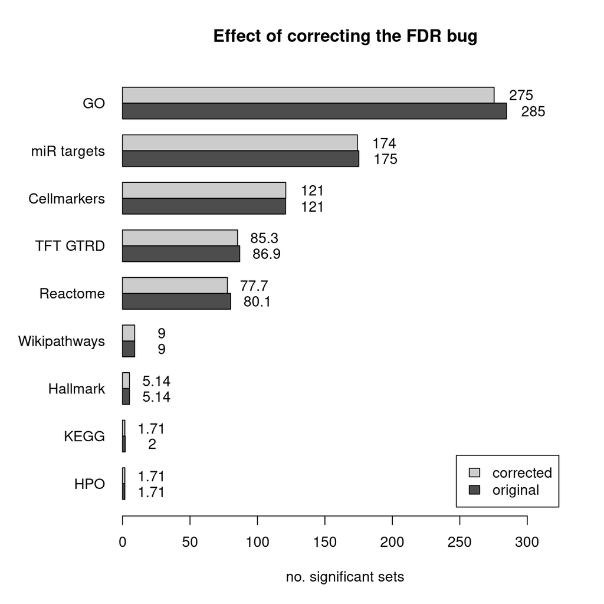

```r
df <- data.frame(ns1,ns2)
df <- df[order(df$ns1),]

par(mar=c(c(5.1, 7.1, 4.1, 2.1) ))
barplot(t(df),beside=TRUE,horiz=TRUE,las=1,xlim=c(0,330),
  xlab="no. significant sets", main="Effect of correcting the FDR bug",
  col=c("gray30","gray80"))
text(df$ns1+20,((1:nrow(df))*3)-1.5,labels=signif(df[,1],3))
text(df$ns2+20,((1:nrow(df))*3)-0.5,labels=signif(df[,2],3))
legend("bottomright", inset=.02, legend=c("corrected","original"),
  fill=c("gray80","gray30"), horiz=FALSE, cex=1)
```

```r
# RATIO
rat <- matrix( (res1$nsig_good+0) / (res1$nsig_bad+0) , ncol=9 )
rownames(rat) <- names(d)
colnames(rat) <- names(gs)

signif(rat,3) %>%
  kbl(row.names = TRUE, caption="Ratio of significant genesets Corrected:Original") %>%
  kable_paper("hover", full_width = F)
```

Ratio of significant genesets Corrected:Original

|  | KEGG | Reactome | Wikipathways | miR targets | TFT GTRD | GO | HPO | Cellmarkers | Hallmark |
| --- | --- | --- | --- | --- | --- | --- | --- | --- | --- |
| bulkrna1.Rds | 1 | 0.992 | 1 | 0.979 | 1.000 | 1.000 | 1 | 0.988 | 1 |
| bulkrna2.Rds | 0 | 1.000 | 1 | 1.000 | 0.989 | 0.966 | 1 | 1.000 | 1 |
| bulkrna3.Rds | 0 | 0.990 | 1 | 1.000 | 0.960 | 0.974 | 1 | 1.000 | 1 |
| bulkrna4.Rds | 1 | 0.972 | NaN | 1.000 | 1.000 | 0.932 | NaN | 1.000 | 1 |
| bulkrna5.Rds | NaN | 0.923 | NaN | 0.996 | 0.982 | 0.958 | NaN | 1.000 | NaN |
| bulkrna6.Rds | 1 | 0.973 | 1 | 0.997 | 0.978 | 0.941 | NaN | 1.000 | 1 |
| bulkrna7.Rds | NaN | 0.708 | 1 | 1.000 | 0.969 | 0.969 | NaN | 1.010 | 1 |

```r
rat2 <- apply(rat,2,function(x) { x <- x[!is.na(x)] ; x <- x[is.finite(x)] ;  mean(x) } )
rat2
```

```
##         KEGG     Reactome Wikipathways  miR targets     TFT GTRD           GO
##    0.6000000    0.9368864    1.0000000    0.9960173    0.9824593    0.9629219
##          HPO  Cellmarkers     Hallmark
##    1.0000000    0.9994483    1.0000000
```

```r
# JACCARD
jac <- matrix( res1$Jaccard , ncol=9 )
rownames(jac) <- names(d)
colnames(jac) <- names(gs)

signif(jac,3) %>%
  kbl(row.names = TRUE, caption="Jaccard similarity Corrected:Original") %>%
  kable_paper("hover", full_width = F)
```

Jaccard similarity Corrected:Original

|  | KEGG | Reactome | Wikipathways | miR targets | TFT GTRD | GO | HPO | Cellmarkers | Hallmark |
| --- | --- | --- | --- | --- | --- | --- | --- | --- | --- |
| bulkrna1.Rds | 1 | 0.992 | 1 | 0.979 | 1.000 | 1.000 | 1 | 0.988 | 1 |
| bulkrna2.Rds | 0 | 1.000 | 1 | 1.000 | 0.989 | 0.966 | 1 | 1.000 | 1 |
| bulkrna3.Rds | 0 | 0.990 | 1 | 1.000 | 0.960 | 0.974 | 1 | 1.000 | 1 |
| bulkrna4.Rds | 1 | 0.972 | NaN | 1.000 | 1.000 | 0.932 | NaN | 1.000 | 1 |
| bulkrna5.Rds | NaN | 0.923 | NaN | 0.996 | 0.982 | 0.958 | NaN | 1.000 | NaN |
| bulkrna6.Rds | 1 | 0.973 | 1 | 0.997 | 0.978 | 0.941 | NaN | 1.000 | 1 |
| bulkrna7.Rds | NaN | 0.708 | 1 | 1.000 | 0.969 | 0.969 | NaN | 0.992 | 1 |

```r
jac2 <- apply(jac,2,function(x) { x <- x[!is.na(x)] ; x <- x[is.finite(x)] ;  mean(x) } )
jac2
```

```
##         KEGG     Reactome Wikipathways  miR targets     TFT GTRD           GO
##    0.6000000    0.9368864    1.0000000    0.9960173    0.9824593    0.9629219
##          HPO  Cellmarkers     Hallmark
##    1.0000000    0.9970772    1.0000000
```

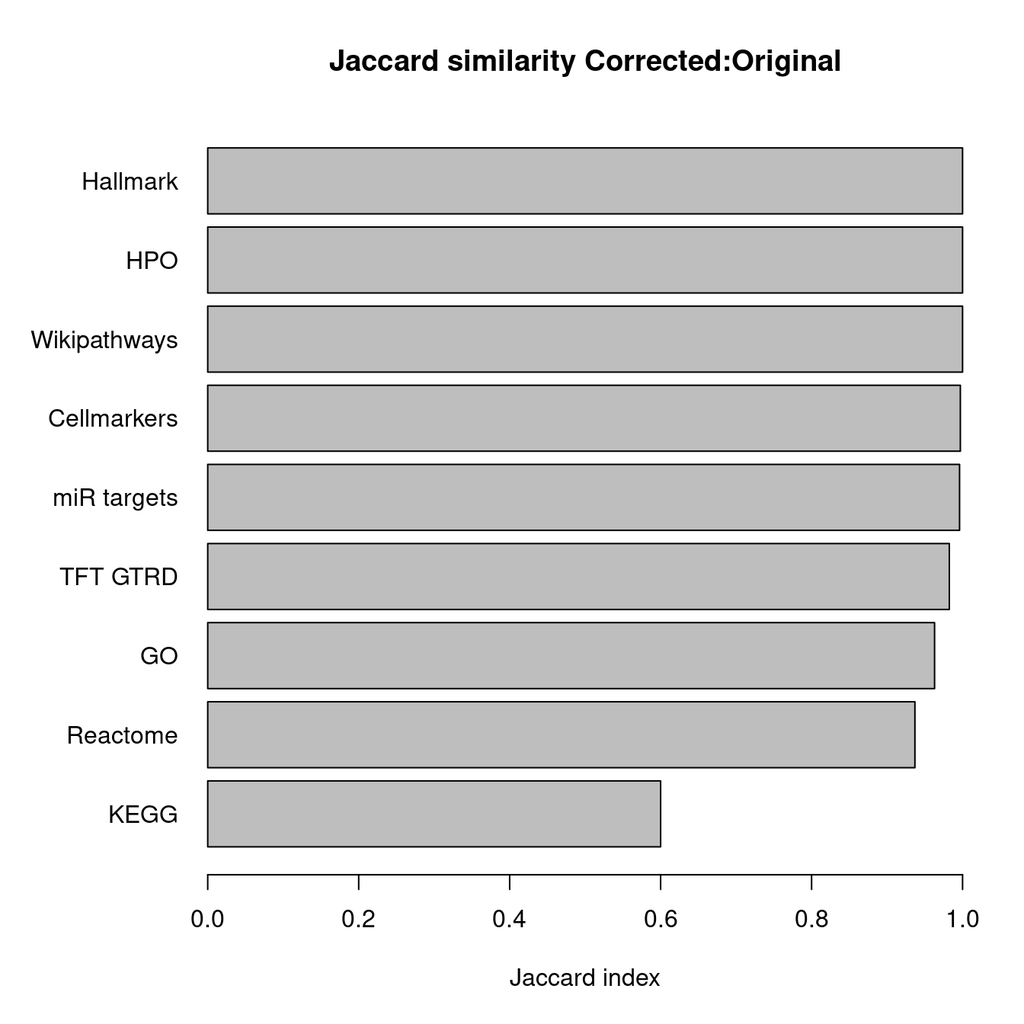

```r
barplot(sort(jac2),horiz=TRUE,las=1,xlim=c(0,1),
  main="Jaccard similarity Corrected:Original",xlab="Jaccard index")
```

```r
# overall
oa <- matrix(paste(res1$nsig_bad,res1$nsig_good,signif(res1$Jaccard,2)),ncol=9)
rownames(oa) <- names(d)
colnames(oa) <- names(gs)

oa %>%
  kbl(row.names = TRUE, caption="Original:Corrected:Jaccard") %>%
  kable_paper("hover", full_width = F)
```

Original:Corrected:Jaccard

|  | KEGG | Reactome | Wikipathways | miR targets | TFT GTRD | GO | HPO | Cellmarkers | Hallmark |
| --- | --- | --- | --- | --- | --- | --- | --- | --- | --- |
| bulkrna1.Rds | 3 3 1 | 122 121 0.99 | 18 18 1 | 188 184 0.98 | 88 88 1 | 289 289 1 | 9 9 1 | 82 81 0.99 | 3 3 1 |
| bulkrna2.Rds | 1 0 0 | 96 96 1 | 18 18 1 | 37 37 1 | 88 87 0.99 | 621 600 0.97 | 2 2 1 | 255 255 1 | 13 13 1 |
| bulkrna3.Rds | 1 0 0 | 98 97 0.99 | 3 3 1 | 3 3 1 | 100 96 0.96 | 269 262 0.97 | 1 1 1 | 91 91 1 | 3 3 1 |
| bulkrna4.Rds | 8 8 1 | 108 105 0.97 | 0 0 NaN | 2 2 1 | 66 66 1 | 88 82 0.93 | 0 0 NaN | 31 31 1 | 2 2 1 |
| bulkrna5.Rds | 0 0 NaN | 39 36 0.92 | 0 0 NaN | 270 269 1 | 113 111 0.98 | 214 205 0.96 | 0 0 NaN | 43 43 1 | 0 0 NaN |
| bulkrna6.Rds | 1 1 1 | 74 72 0.97 | 18 18 1 | 690 688 1 | 89 87 0.98 | 188 177 0.94 | 0 0 NaN | 104 104 1 | 12 12 1 |
| bulkrna7.Rds | 0 0 NaN | 24 17 0.71 | 6 6 1 | 36 36 1 | 64 62 0.97 | 323 313 0.97 | 0 0 NaN | 240 242 0.99 | 3 3 1 |

Now run an exhaustive analysis, changing the gene list length from 125 to 2000.

```r
ngenes <- c(125,250,500,1000,2000)
params <- expand.grid(1:length(d),1:length(gs),ngenes)
params2 <- expand.grid(names(d),names(gs),ngenes)

colnames(params) <- c("d","gs","ngenes")

ora_dat <- mclapply(1:nrow(params), function(i) {
  j=params[i,1]
  k=params[i,2]
  l=params[i,3]
  bad <- orabad(d[[j]],gs[[k]],l)
  good <- oragood(d[[j]],gs[[k]],l)
  res <- compare_ora(bad,good)
  return(res)
} , mc.cores=8)

ora_dat <- do.call(rbind,ora_dat)

res1 <- cbind(params2,ora_dat)

res1 %>%
  kbl(row.names = TRUE, caption="all results") %>%
  kable_paper("hover", full_width = F)
```

all results

|  | Var1 | Var2 | Var3 | nsig_bad | nsig_good | Jaccard |
| --- | --- | --- | --- | --- | --- | --- |
| 1 | bulkrna1.Rds | KEGG | 125 | 0 | 0 | NaN |
| 2 | bulkrna2.Rds | KEGG | 125 | 0 | 0 | NaN |
| 3 | bulkrna3.Rds | KEGG | 125 | 0 | 0 | NaN |
| 4 | bulkrna4.Rds | KEGG | 125 | 0 | 0 | NaN |
| 5 | bulkrna5.Rds | KEGG | 125 | 0 | 0 | NaN |
| 6 | bulkrna6.Rds | KEGG | 125 | 0 | 0 | NaN |
| 7 | bulkrna7.Rds | KEGG | 125 | 0 | 0 | NaN |
| 8 | bulkrna1.Rds | Reactome | 125 | 0 | 0 | NaN |
| 9 | bulkrna2.Rds | Reactome | 125 | 0 | 0 | NaN |
| 10 | bulkrna3.Rds | Reactome | 125 | 0 | 0 | NaN |
| 11 | bulkrna4.Rds | Reactome | 125 | 0 | 0 | NaN |
| 12 | bulkrna5.Rds | Reactome | 125 | 0 | 0 | NaN |
| 13 | bulkrna6.Rds | Reactome | 125 | 0 | 0 | NaN |
| 14 | bulkrna7.Rds | Reactome | 125 | 0 | 0 | NaN |
| 15 | bulkrna1.Rds | Wikipathways | 125 | 0 | 0 | NaN |
| 16 | bulkrna2.Rds | Wikipathways | 125 | 1 | 0 | 0.0000000 |
| 17 | bulkrna3.Rds | Wikipathways | 125 | 0 | 0 | NaN |
| 18 | bulkrna4.Rds | Wikipathways | 125 | 0 | 0 | NaN |
| 19 | bulkrna5.Rds | Wikipathways | 125 | 0 | 0 | NaN |
| 20 | bulkrna6.Rds | Wikipathways | 125 | 0 | 0 | NaN |
| 21 | bulkrna7.Rds | Wikipathways | 125 | 0 | 0 | NaN |
| 22 | bulkrna1.Rds | miR targets | 125 | 0 | 0 | NaN |
| 23 | bulkrna2.Rds | miR targets | 125 | 0 | 0 | NaN |
| 24 | bulkrna3.Rds | miR targets | 125 | 0 | 0 | NaN |
| 25 | bulkrna4.Rds | miR targets | 125 | 0 | 0 | NaN |
| 26 | bulkrna5.Rds | miR targets | 125 | 0 | 0 | NaN |
| 27 | bulkrna6.Rds | miR targets | 125 | 0 | 0 | NaN |
| 28 | bulkrna7.Rds | miR targets | 125 | 0 | 0 | NaN |
| 29 | bulkrna1.Rds | TFT GTRD | 125 | 0 | 0 | NaN |
| 30 | bulkrna2.Rds | TFT GTRD | 125 | 0 | 0 | NaN |

[output cut: 285 more lines]

```r
summary(res1$nsig_bad)
```

```
##    Min. 1st Qu.  Median    Mean 3rd Qu.    Max.
##     0.0     0.0     1.0    25.2    10.5   690.0
```

```r
summary(res1$nsig_good)
```

```
##    Min. 1st Qu.  Median    Mean 3rd Qu.    Max.
##    0.00    0.00    0.00   23.92    8.00  688.00
```

```r
summary(res1$Jaccard)
```

```
##    Min. 1st Qu.  Median    Mean 3rd Qu.    Max.    NA's
##  0.0000  0.8779  1.0000  0.8465  1.0000  1.0000     157
```

```r
lapply(ngenes, function(n) {
  res2 <- subset(res1,Var3==n) ; summary(res2$nsig_bad)
} )
```

```
## [[1]]
##    Min. 1st Qu.  Median    Mean 3rd Qu.    Max.
##  0.0000  0.0000  0.0000  0.5238  0.0000 13.0000
##
## [[2]]
##    Min. 1st Qu.  Median    Mean 3rd Qu.    Max.
##   0.000   0.000   0.000   2.222   1.000  32.000
##
## [[3]]
##    Min. 1st Qu.  Median    Mean 3rd Qu.    Max.
##   0.000   0.000   0.000   6.254   3.000 115.000
##
## [[4]]
##    Min. 1st Qu.  Median    Mean 3rd Qu.    Max.
##    0.00    0.00    3.00   31.94   41.50  307.00
##
## [[5]]
##    Min. 1st Qu.  Median    Mean 3rd Qu.    Max.
##    0.00    2.50   31.00   85.05   99.00  690.00
```

```r
lapply(ngenes, function(n) {
  res2 <- subset(res1,Var3==n) ; summary(res2$nsig_good)
} )
```

```
## [[1]]
##    Min. 1st Qu.  Median    Mean 3rd Qu.    Max.
##  0.0000  0.0000  0.0000  0.1111  0.0000  6.0000
##
## [[2]]
##    Min. 1st Qu.  Median    Mean 3rd Qu.    Max.
##   0.000   0.000   0.000   1.603   1.000  30.000
##
## [[3]]
##    Min. 1st Qu.  Median    Mean 3rd Qu.    Max.
##    0.00    0.00    0.00    5.19    2.00  108.00
##
## [[4]]
##    Min. 1st Qu.  Median    Mean 3rd Qu.    Max.
##    0.00    0.00    3.00   29.22   38.00  305.00
##
## [[5]]
##    Min. 1st Qu.  Median    Mean 3rd Qu.    Max.
##    0.00    2.50   31.00   83.46   96.50  688.00
```

```r
lapply(ngenes, function(n) {
  res2 <- subset(res1,Var3==n) ; summary(res2$Jaccard)
} )
```

```
## [[1]]
##    Min. 1st Qu.  Median    Mean 3rd Qu.    Max.    NA's
##  0.0000  0.0000  0.0000  0.1667  0.0000  1.0000      53
##
## [[2]]
##    Min. 1st Qu.  Median    Mean 3rd Qu.    Max.    NA's
##  0.0000  0.5000  1.0000  0.7063  1.0000  1.0000      38
##
## [[3]]
##    Min. 1st Qu.  Median    Mean 3rd Qu.    Max.    NA's
##  0.0000  0.8125  1.0000  0.8711  1.0000  1.0000      39
##
## [[4]]
##    Min. 1st Qu.  Median    Mean 3rd Qu.    Max.    NA's
##  0.7273  0.8835  1.0000  0.9419  1.0000  1.0000      18
##
## [[5]]
##    Min. 1st Qu.  Median    Mean 3rd Qu.    Max.    NA's
##  0.0000  0.9749  1.0000  0.9468  1.0000  1.0000       9
```

```r
# NUMBER OF SIGNIFICANT SETS

ns1 <- lapply(ngenes ,function(n) {
  res2 <- subset(res1,Var3==n)
  ns <- matrix( res2$nsig_bad , ncol=9 )
  rownames(ns) <- names(d)
  colnames(ns) <- names(gs)
  return(ns)
} )

names(ns1) <- ngenes

ns1
```

```
## $`125`
##              KEGG Reactome Wikipathways miR targets TFT GTRD GO HPO Cellmarkers
## bulkrna1.Rds    0        0            0           0        0  9   2           0
## bulkrna2.Rds    0        0            1           0        0  0   0           2
## bulkrna3.Rds    0        0            0           0        0  0   0           0
## bulkrna4.Rds    0        0            0           0        0  0   1           2
## bulkrna5.Rds    0        0            0           0        0 13   0           0
## bulkrna6.Rds    0        0            0           0        0  0   0           0
## bulkrna7.Rds    0        0            0           0        0  1   1           0
##              Hallmark
## bulkrna1.Rds        0
## bulkrna2.Rds        0
## bulkrna3.Rds        0
## bulkrna4.Rds        0
## bulkrna5.Rds        1
## bulkrna6.Rds        0
## bulkrna7.Rds        0
##
## $`250`
##              KEGG Reactome Wikipathways miR targets TFT GTRD GO HPO Cellmarkers
## bulkrna1.Rds    0        0            0           0        0  1   0           0
## bulkrna2.Rds    2        3            0           0        7 16   0          32
## bulkrna3.Rds    0        0            0           0        1  0   3           4
## bulkrna4.Rds    0        0            0           0        1  0   0           2
## bulkrna5.Rds    0        0            1           1        1 20   0           0
## bulkrna6.Rds    0        0            0           1        2  0   0           4
## bulkrna7.Rds    0        2            1           0        1  0  19          12
##              Hallmark
## bulkrna1.Rds        0
## bulkrna2.Rds        1
## bulkrna3.Rds        0
## bulkrna4.Rds        0
## bulkrna5.Rds        0
## bulkrna6.Rds        2
## bulkrna7.Rds        0
##
## $`500`
##              KEGG Reactome Wikipathways miR targets TFT GTRD GO HPO Cellmarkers
## bulkrna1.Rds    0        0            0           7       11 19   0           2
## bulkrna2.Rds    0        3            0           0        6 69   0          45
```

[output cut: 34 more lines]

```
## bulkrna1.Rds    3      122           18         188       88 289   9
## bulkrna2.Rds    1       96           18          37       88 621   2
## bulkrna3.Rds    1       98            3           3      100 269   1
## bulkrna4.Rds    8      108            0           2       66  88   0
## bulkrna5.Rds    0       39            0         270      113 214   0
## bulkrna6.Rds    1       74           18         690       89 188   0
## bulkrna7.Rds    0       24            6          36       64 323   0
##              Cellmarkers Hallmark
## bulkrna1.Rds          82        3
## bulkrna2.Rds         255       13
## bulkrna3.Rds          91        3
## bulkrna4.Rds          31        2
## bulkrna5.Rds          43        0
## bulkrna6.Rds         104       12
## bulkrna7.Rds         240        3
```

```r
ns1 <- lapply(ns1,function(y) {
  res <- apply(y,2,function(x) {
    x <- x[!is.na(x)]
    x <- x[is.finite(x)]
    mean(x)
  } )
  return(res)
})

ns1
```

```
## $`125`
##         KEGG     Reactome Wikipathways  miR targets     TFT GTRD           GO
##    0.0000000    0.0000000    0.1428571    0.0000000    0.0000000    3.2857143
##          HPO  Cellmarkers     Hallmark
##    0.5714286    0.5714286    0.1428571
##
## $`250`
##         KEGG     Reactome Wikipathways  miR targets     TFT GTRD           GO
##    0.2857143    0.7142857    0.2857143    0.2857143    1.8571429    5.2857143
##          HPO  Cellmarkers     Hallmark
##    3.1428571    7.7142857    0.4285714
##
## $`500`
##         KEGG     Reactome Wikipathways  miR targets     TFT GTRD           GO
##    0.0000000    0.4285714    0.0000000   19.0000000    4.7142857   19.2857143
##          HPO  Cellmarkers     Hallmark
##    0.0000000   12.8571429    0.0000000
##
## $`1000`
##         KEGG     Reactome Wikipathways  miR targets     TFT GTRD           GO
##     0.000000    47.428571     1.285714    59.142857    31.428571    95.000000
##          HPO  Cellmarkers     Hallmark
##     1.000000    49.714286     2.428571
##
## $`2000`
##         KEGG     Reactome Wikipathways  miR targets     TFT GTRD           GO
##     2.000000    80.142857     9.000000   175.142857    86.857143   284.571429
##          HPO  Cellmarkers     Hallmark
##     1.714286   120.857143     5.142857
```

```r
ns2 <- lapply(ngenes ,function(n) {
  res2 <- subset(res1,Var3==n)
  ns <- matrix( res2$nsig_good , ncol=9 )
  rownames(ns) <- names(d)
  colnames(ns) <- names(gs)
  return(ns)
} )

names(ns2) <- ngenes

ns2
```

```
## $`125`
##              KEGG Reactome Wikipathways miR targets TFT GTRD GO HPO Cellmarkers
## bulkrna1.Rds    0        0            0           0        0  6   0           0
## bulkrna2.Rds    0        0            0           0        0  0   0           0
## bulkrna3.Rds    0        0            0           0        0  0   0           0
## bulkrna4.Rds    0        0            0           0        0  0   0           0
## bulkrna5.Rds    0        0            0           0        0  0   0           0
## bulkrna6.Rds    0        0            0           0        0  0   0           0
## bulkrna7.Rds    0        0            0           0        0  0   1           0
##              Hallmark
## bulkrna1.Rds        0
## bulkrna2.Rds        0
## bulkrna3.Rds        0
## bulkrna4.Rds        0
## bulkrna5.Rds        0
## bulkrna6.Rds        0
## bulkrna7.Rds        0
##
## $`250`
##              KEGG Reactome Wikipathways miR targets TFT GTRD GO HPO Cellmarkers
## bulkrna1.Rds    0        0            0           0        0  0   0           0
## bulkrna2.Rds    1        3            0           0        5 12   0          30
## bulkrna3.Rds    0        0            0           0        1  0   1           4
## bulkrna4.Rds    0        0            0           0        1  0   0           2
## bulkrna5.Rds    0        0            0           1        1 10   0           0
## bulkrna6.Rds    0        0            0           1        2  0   0           2
## bulkrna7.Rds    0        0            1           0        0  0   8          12
##              Hallmark
## bulkrna1.Rds        0
## bulkrna2.Rds        1
## bulkrna3.Rds        0
## bulkrna4.Rds        0
## bulkrna5.Rds        0
## bulkrna6.Rds        2
## bulkrna7.Rds        0
##
## $`500`
##              KEGG Reactome Wikipathways miR targets TFT GTRD GO HPO Cellmarkers
## bulkrna1.Rds    0        0            0           7       11  9   0           2
## bulkrna2.Rds    0        2            0           0        5 42   0          45
```

[output cut: 34 more lines]

```
## bulkrna1.Rds    3      121           18         184       88 289   9
## bulkrna2.Rds    0       96           18          37       87 600   2
## bulkrna3.Rds    0       97            3           3       96 262   1
## bulkrna4.Rds    8      105            0           2       66  82   0
## bulkrna5.Rds    0       36            0         269      111 205   0
## bulkrna6.Rds    1       72           18         688       87 177   0
## bulkrna7.Rds    0       17            6          36       62 313   0
##              Cellmarkers Hallmark
## bulkrna1.Rds          81        3
## bulkrna2.Rds         255       13
## bulkrna3.Rds          91        3
## bulkrna4.Rds          31        2
## bulkrna5.Rds          43        0
## bulkrna6.Rds         104       12
## bulkrna7.Rds         242        3
```

```r
ns2 <- lapply(ns2,function(y) {
  res <- apply(y,2,function(x) {
    x <- x[!is.na(x)]
    x <- x[is.finite(x)]
    mean(x)
  } )
  return(res)
})

ns2
```

```
## $`125`
##         KEGG     Reactome Wikipathways  miR targets     TFT GTRD           GO
##    0.0000000    0.0000000    0.0000000    0.0000000    0.0000000    0.8571429
##          HPO  Cellmarkers     Hallmark
##    0.1428571    0.0000000    0.0000000
##
## $`250`
##         KEGG     Reactome Wikipathways  miR targets     TFT GTRD           GO
##    0.1428571    0.4285714    0.1428571    0.2857143    1.4285714    3.1428571
##          HPO  Cellmarkers     Hallmark
##    1.2857143    7.1428571    0.4285714
##
## $`500`
##         KEGG     Reactome Wikipathways  miR targets     TFT GTRD           GO
##    0.0000000    0.2857143    0.0000000   18.0000000    4.5714286   11.2857143
##          HPO  Cellmarkers     Hallmark
##    0.0000000   12.5714286    0.0000000
##
## $`1000`
##         KEGG     Reactome Wikipathways  miR targets     TFT GTRD           GO
##     0.000000    40.857143     1.285714    58.714286    30.428571    79.857143
##          HPO  Cellmarkers     Hallmark
##     1.000000    48.428571     2.428571
##
## $`2000`
##         KEGG     Reactome Wikipathways  miR targets     TFT GTRD           GO
##     1.714286    77.714286     9.000000   174.142857    85.285714   275.428571
##          HPO  Cellmarkers     Hallmark
##     1.714286   121.000000     5.142857
```

```r
# JACCARD
jac <- lapply(ngenes ,function(n) {
  res2 <- subset(res1,Var3==n)
  ns <- matrix( res2$Jaccard , ncol=9 )
  rownames(ns) <- names(d)
  colnames(ns) <- names(gs)
  return(ns)
} )
names(jac) <- ngenes

jac
```

```
## $`125`
##              KEGG Reactome Wikipathways miR targets TFT GTRD        GO HPO
## bulkrna1.Rds  NaN      NaN          NaN         NaN      NaN 0.6666667   0
## bulkrna2.Rds  NaN      NaN            0         NaN      NaN       NaN NaN
## bulkrna3.Rds  NaN      NaN          NaN         NaN      NaN       NaN NaN
## bulkrna4.Rds  NaN      NaN          NaN         NaN      NaN       NaN   0
## bulkrna5.Rds  NaN      NaN          NaN         NaN      NaN 0.0000000 NaN
## bulkrna6.Rds  NaN      NaN          NaN         NaN      NaN       NaN NaN
## bulkrna7.Rds  NaN      NaN          NaN         NaN      NaN 0.0000000   1
##              Cellmarkers Hallmark
## bulkrna1.Rds         NaN      NaN
## bulkrna2.Rds           0      NaN
## bulkrna3.Rds         NaN      NaN
## bulkrna4.Rds           0      NaN
## bulkrna5.Rds         NaN        0
## bulkrna6.Rds         NaN      NaN
## bulkrna7.Rds         NaN      NaN
##
## $`250`
##              KEGG Reactome Wikipathways miR targets  TFT GTRD   GO       HPO
## bulkrna1.Rds  NaN      NaN          NaN         NaN       NaN 0.00       NaN
## bulkrna2.Rds  0.5        1          NaN         NaN 0.7142857 0.75       NaN
## bulkrna3.Rds  NaN      NaN          NaN         NaN 1.0000000  NaN 0.3333333
## bulkrna4.Rds  NaN      NaN          NaN         NaN 1.0000000  NaN       NaN
## bulkrna5.Rds  NaN      NaN            0           1 1.0000000 0.50       NaN
## bulkrna6.Rds  NaN      NaN          NaN           1 1.0000000  NaN       NaN
## bulkrna7.Rds  NaN        0            1         NaN 0.0000000  NaN 0.4210526
##              Cellmarkers Hallmark
## bulkrna1.Rds         NaN      NaN
## bulkrna2.Rds      0.9375        1
## bulkrna3.Rds      1.0000      NaN
## bulkrna4.Rds      1.0000      NaN
## bulkrna5.Rds         NaN      NaN
## bulkrna6.Rds      0.5000        1
## bulkrna7.Rds      1.0000      NaN
##
## $`500`
##              KEGG  Reactome Wikipathways miR targets  TFT GTRD        GO HPO
## bulkrna1.Rds  NaN       NaN          NaN   1.0000000 1.0000000 0.4736842 NaN
## bulkrna2.Rds  NaN 0.6666667          NaN         NaN 0.8333333 0.6086957 NaN
```

[output cut: 34 more lines]

```
## bulkrna1.Rds    1 0.9918033            1   0.9787234 1.0000000 1.0000000   1
## bulkrna2.Rds    0 1.0000000            1   1.0000000 0.9886364 0.9661836   1
## bulkrna3.Rds    0 0.9897959            1   1.0000000 0.9600000 0.9739777   1
## bulkrna4.Rds    1 0.9722222          NaN   1.0000000 1.0000000 0.9318182 NaN
## bulkrna5.Rds  NaN 0.9230769          NaN   0.9962963 0.9823009 0.9579439 NaN
## bulkrna6.Rds    1 0.9729730            1   0.9971014 0.9775281 0.9414894 NaN
## bulkrna7.Rds  NaN 0.7083333            1   1.0000000 0.9687500 0.9690402 NaN
##              Cellmarkers Hallmark
## bulkrna1.Rds   0.9878049        1
## bulkrna2.Rds   1.0000000        1
## bulkrna3.Rds   1.0000000        1
## bulkrna4.Rds   1.0000000        1
## bulkrna5.Rds   1.0000000      NaN
## bulkrna6.Rds   1.0000000        1
## bulkrna7.Rds   0.9917355        1
```

```r
jac <- lapply(jac,function(y) {
  res <- apply(y,2,function(x) {
    x <- x[!is.na(x)]
    x <- x[is.finite(x)]
    mean(x)
  } )
  return(res)
})

jac
```

```
## $`125`
##         KEGG     Reactome Wikipathways  miR targets     TFT GTRD           GO
##          NaN          NaN    0.0000000          NaN          NaN    0.2222222
##          HPO  Cellmarkers     Hallmark
##    0.3333333    0.0000000    0.0000000
##
## $`250`
##         KEGG     Reactome Wikipathways  miR targets     TFT GTRD           GO
##    0.5000000    0.5000000    0.5000000    1.0000000    0.7857143    0.4166667
##          HPO  Cellmarkers     Hallmark
##    0.3771930    0.8875000    1.0000000
##
## $`500`
##         KEGG     Reactome Wikipathways  miR targets     TFT GTRD           GO
##          NaN    0.6666667          NaN    0.9847826    0.9761905    0.6248411
##          HPO  Cellmarkers     Hallmark
##          NaN    0.9531250          NaN
##
## $`1000`
##         KEGG     Reactome Wikipathways  miR targets     TFT GTRD           GO
##          NaN    0.8390101    1.0000000    0.9969985    0.9639873    0.8145344
##          HPO  Cellmarkers     Hallmark
##    1.0000000    0.9653202    1.0000000
##
## $`2000`
##         KEGG     Reactome Wikipathways  miR targets     TFT GTRD           GO
##    0.6000000    0.9368864    1.0000000    0.9960173    0.9824593    0.9629219
##          HPO  Cellmarkers     Hallmark
##    1.0000000    0.9970772    1.0000000
```

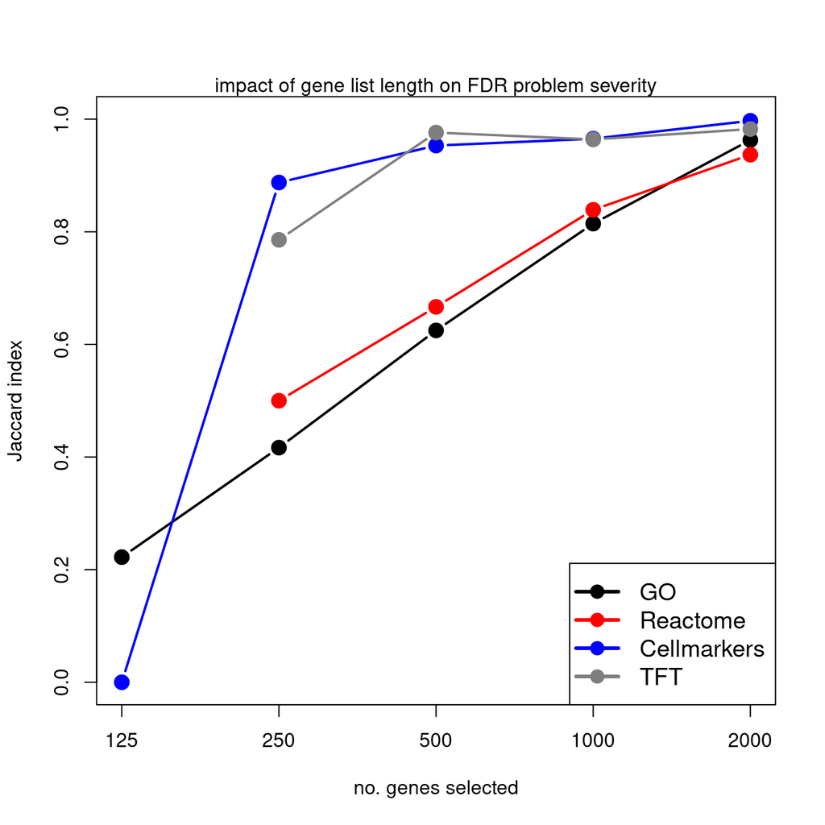

```r
jac <- do.call(rbind,jac)

plot(jac[,"GO"],type="b", pch=19,cex=1.5,lwd=2,
  xaxt = "n",ylim=c(0,1),ylab="Jaccard index",xlab="no. genes selected")
axis(1, at = seq(1, 5, by = 1),
     labels = ngenes)
points(jac[,"Reactome"],type="b",col="red",pch=19,cex=1.5,lwd=2)
points(jac[,"Cellmarkers"],type="b",col="blue",pch=19,cex=1.5,lwd=2)
points(jac[,"TFT GTRD"],type="b",col="gray50",pch=19,cex=1.5,lwd=2)
mtext("impact of gene list length on FDR problem severity")

legend("bottomright", legend=c("GO","Reactome", "Cellmarkers", "TFT"),
       col=c("black", "red", "blue", "gray50"), lty=1, cex=1.2,lwd=3,pch=19)
```

## Make charts showing changes in pvalues

For bulk RNA-seq data set #1, run enrichment with all the gene set libraries.

```r
names(gs)
```

```
## [1] "KEGG"         "Reactome"     "Wikipathways" "miR targets"  "TFT GTRD"
## [6] "GO"           "HPO"          "Cellmarkers"  "Hallmark"
```

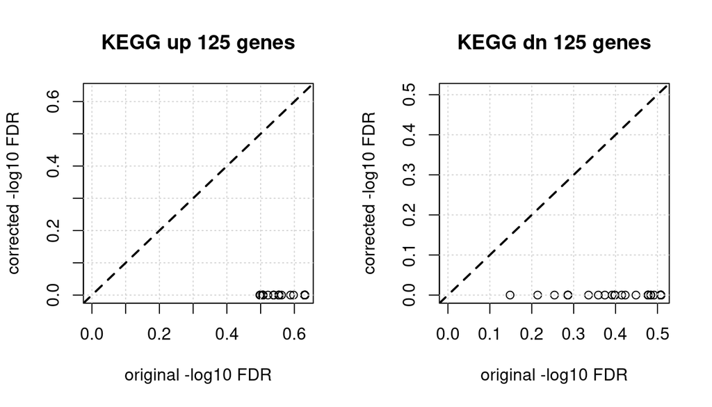

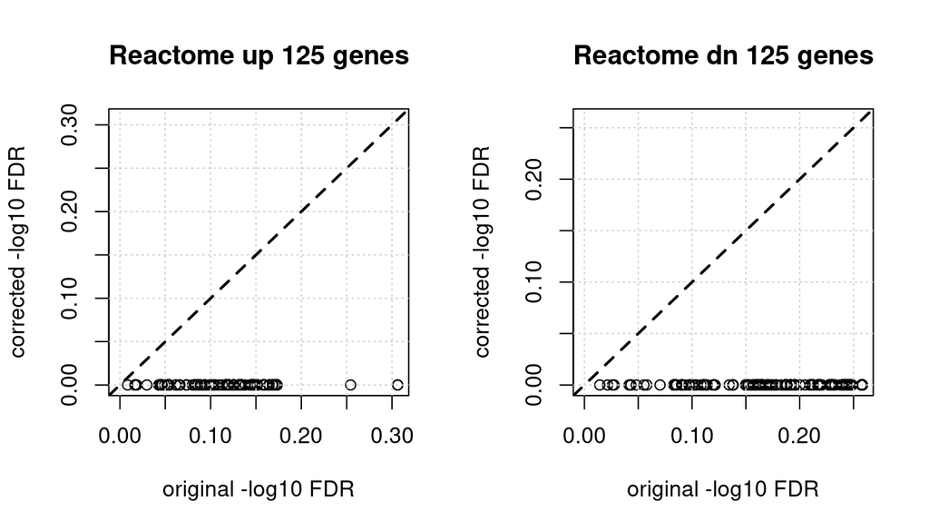

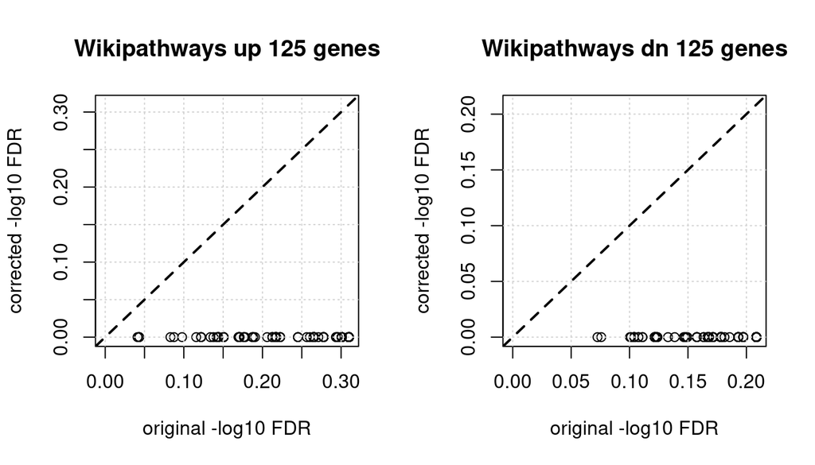

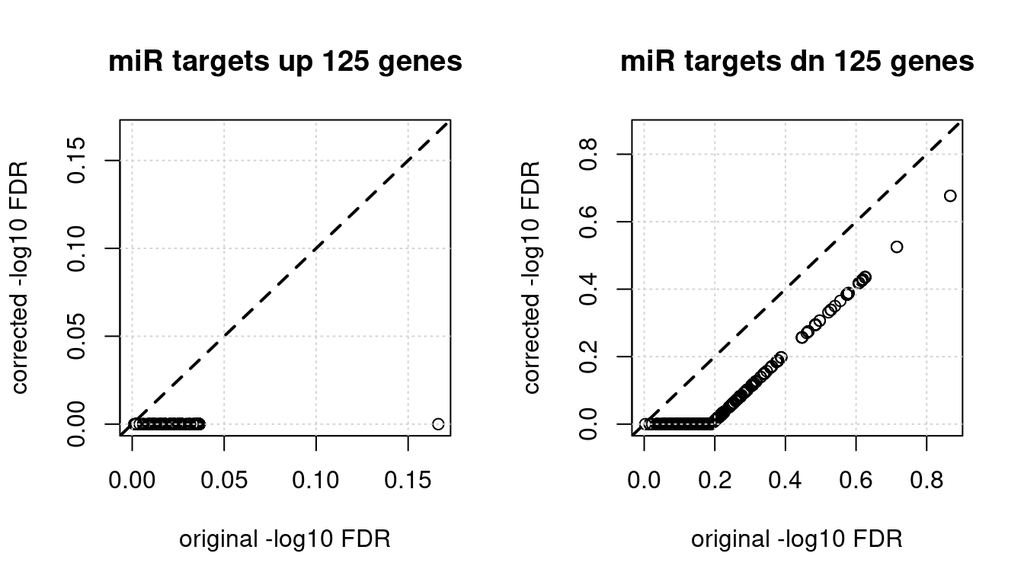

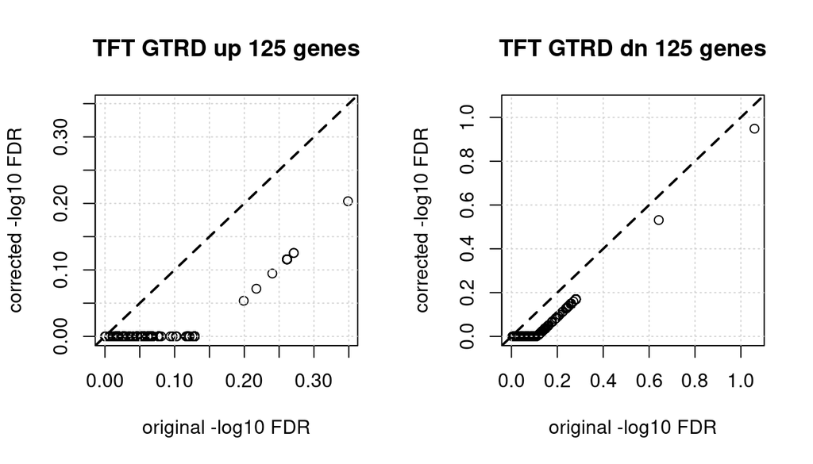

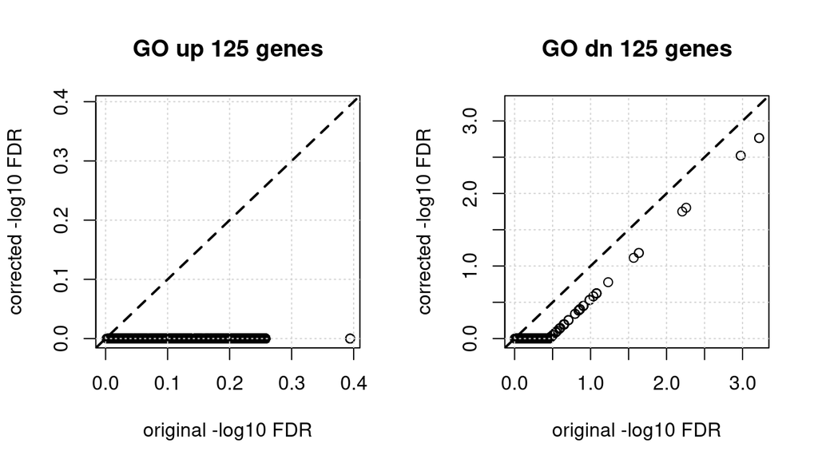

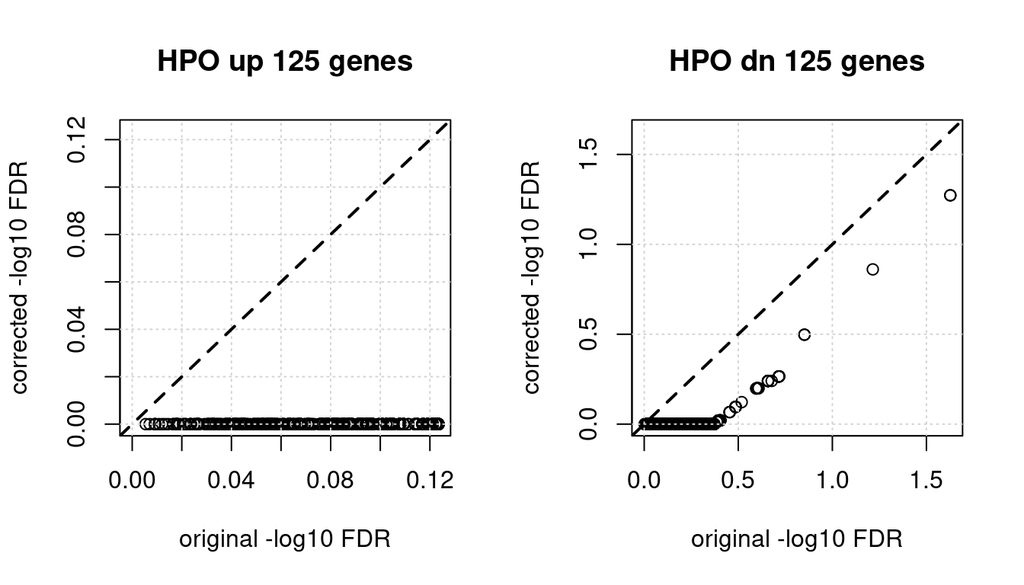

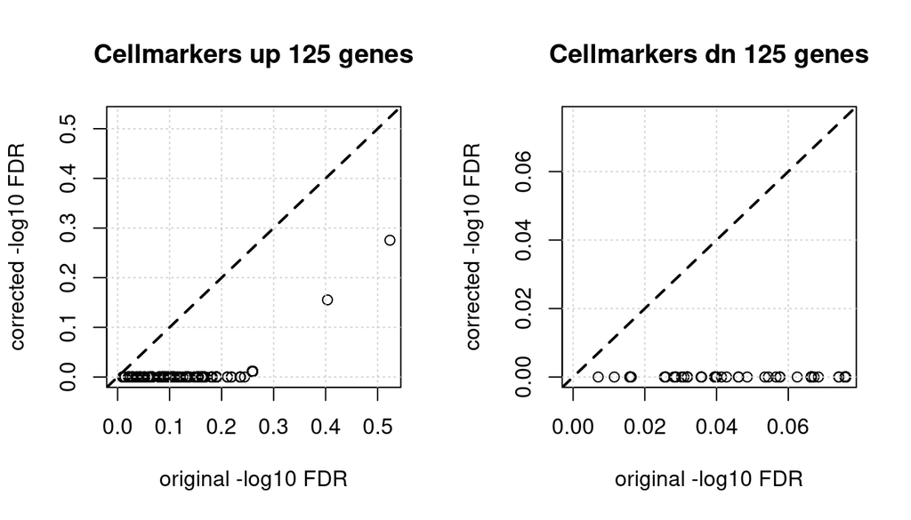

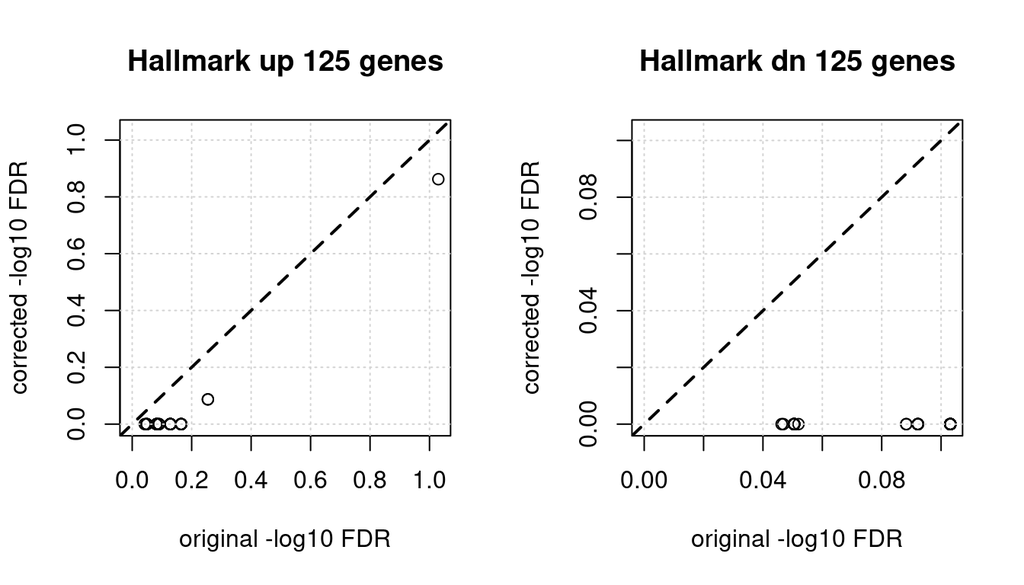

```r
lapply(1:length(gs), function(i) {
  bad <- orabad(d[[1]],gs[[i]],ngenes=125)
  good <- oragood(d[[1]],gs[[i]],ngenes=125)
  compare_ora_plots(bad,good,libname=names(gs)[i],setsize=125)
} )
```

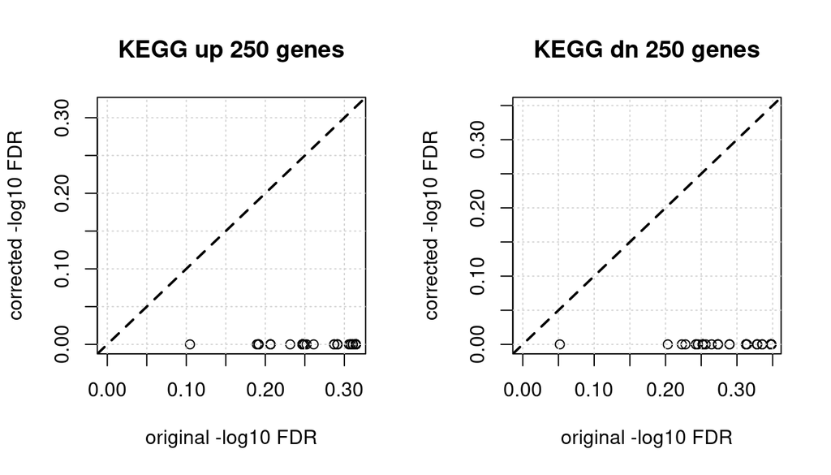

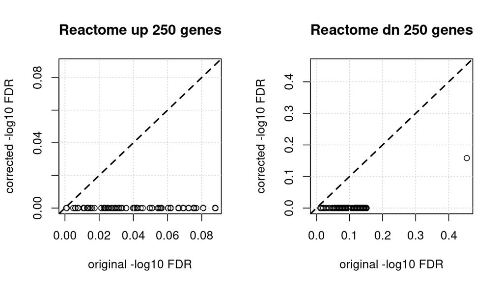

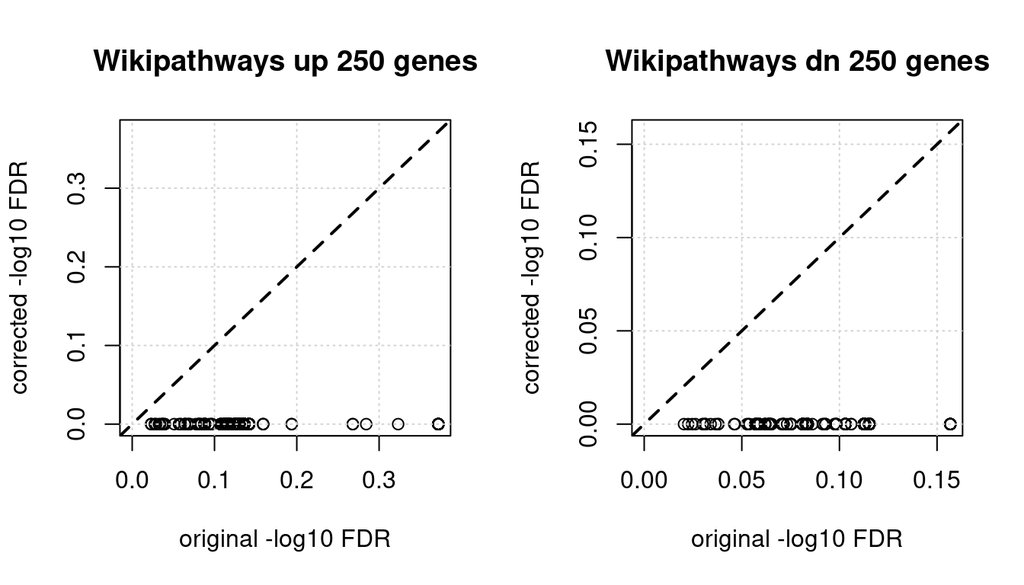

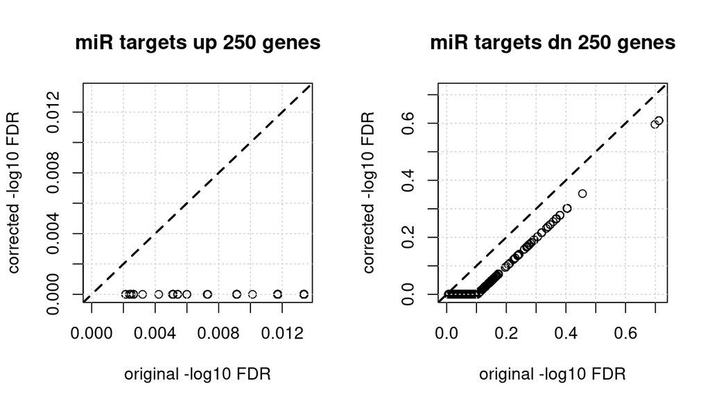

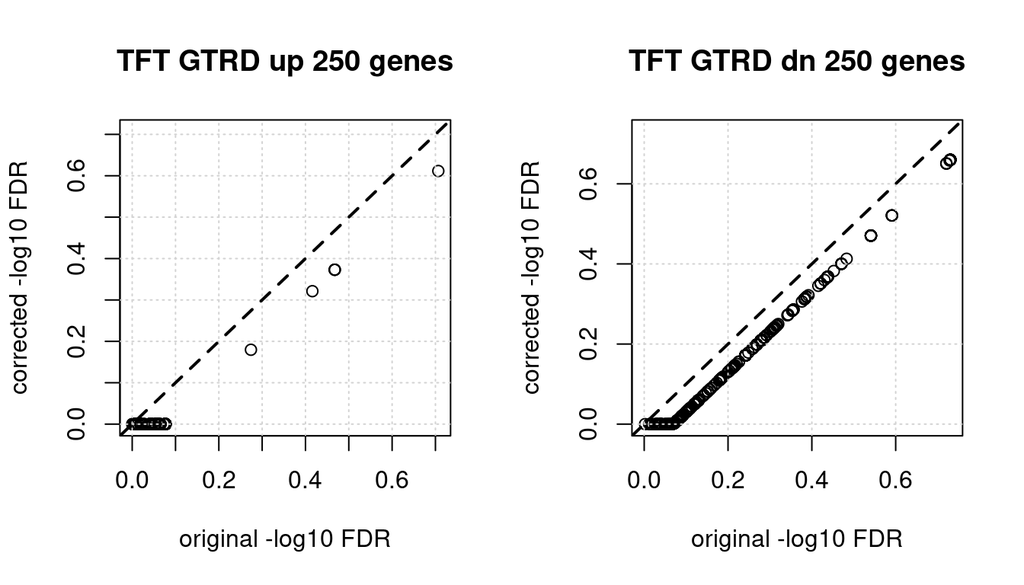

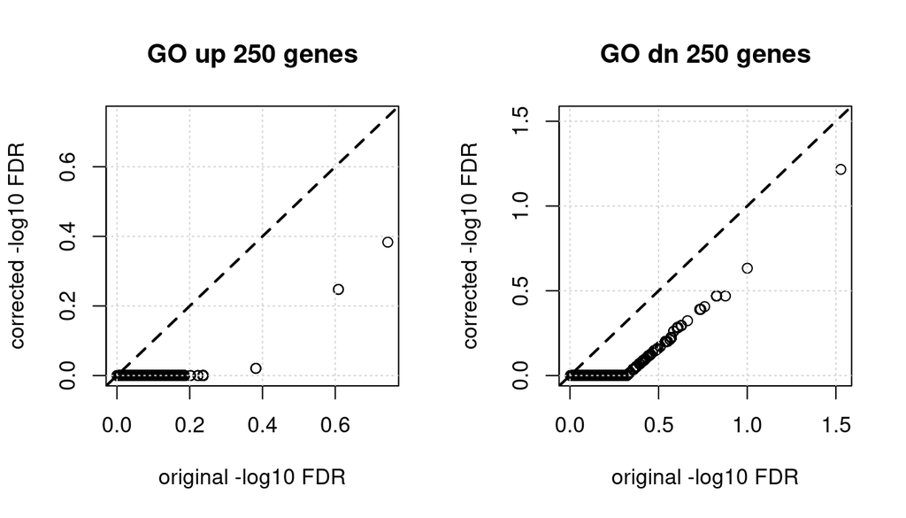

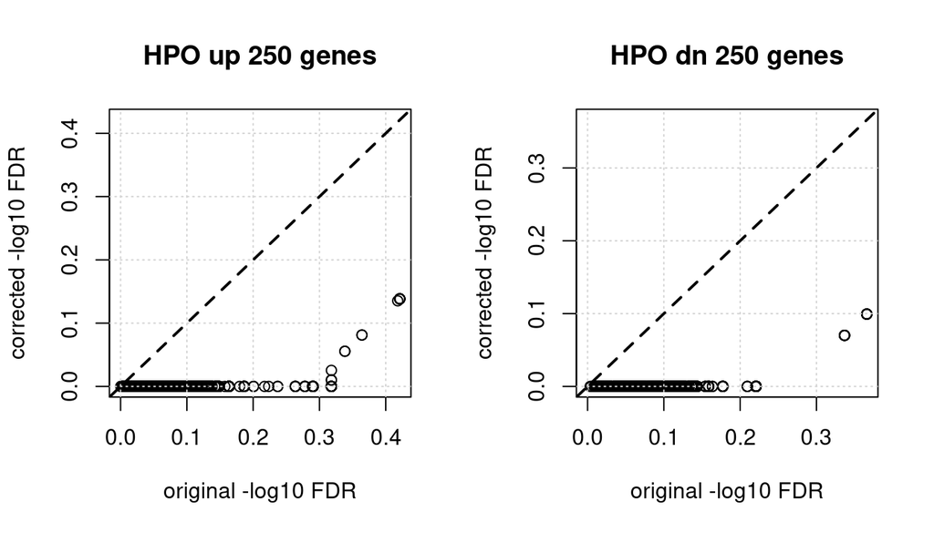

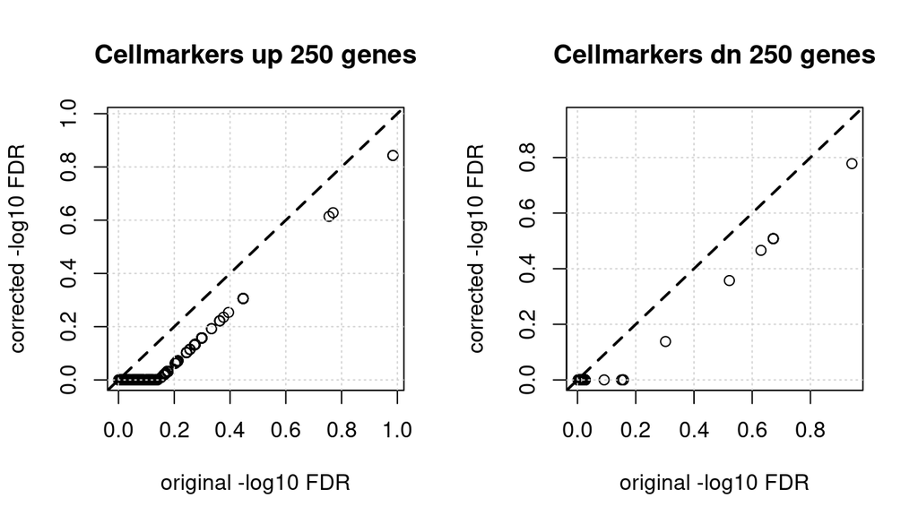

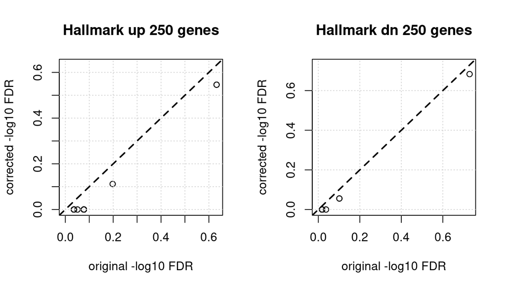

```r
lapply(1:length(gs), function(i) {
  bad <- orabad(d[[1]],gs[[i]],ngenes=250)
  good <- oragood(d[[1]],gs[[i]],ngenes=250)
  compare_ora_plots(bad,good,libname=names(gs)[i],setsize=250)
} )
```

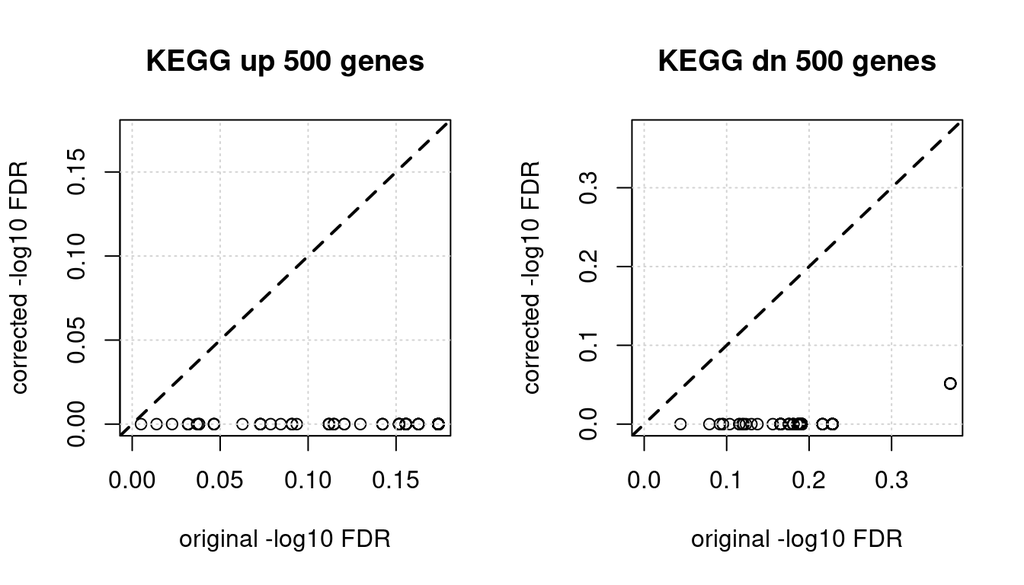

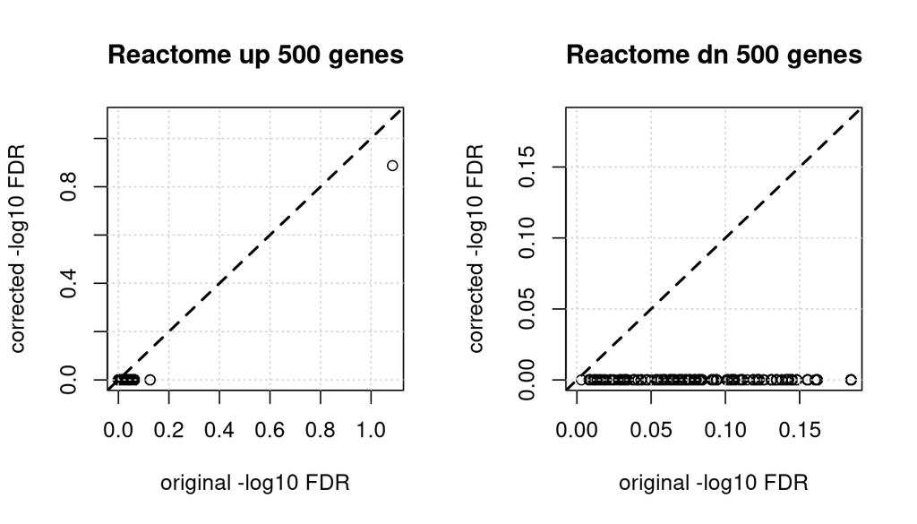

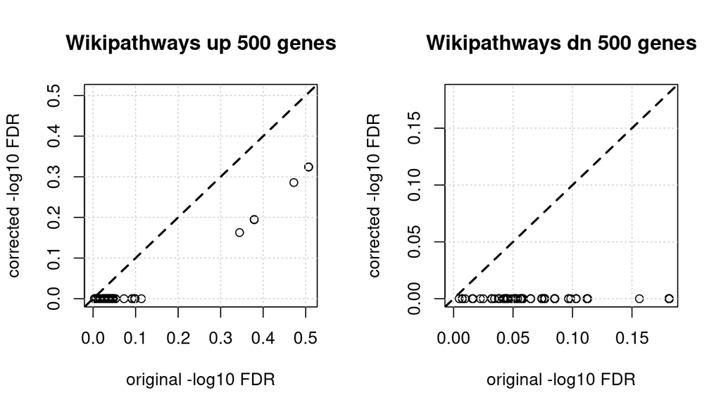

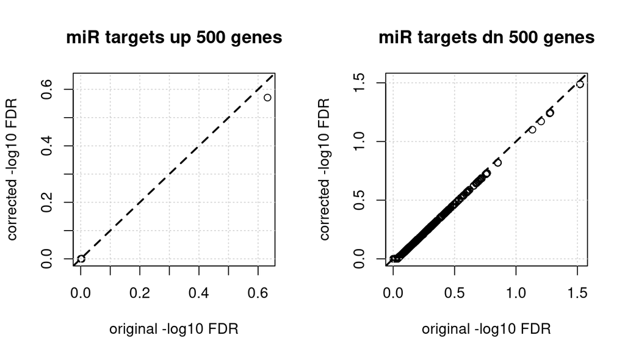

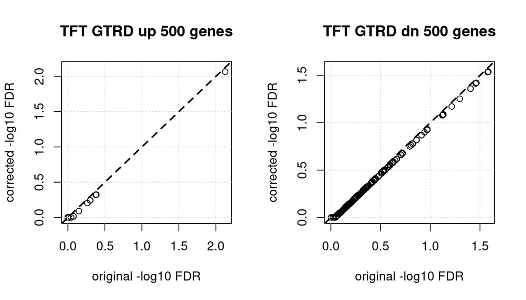

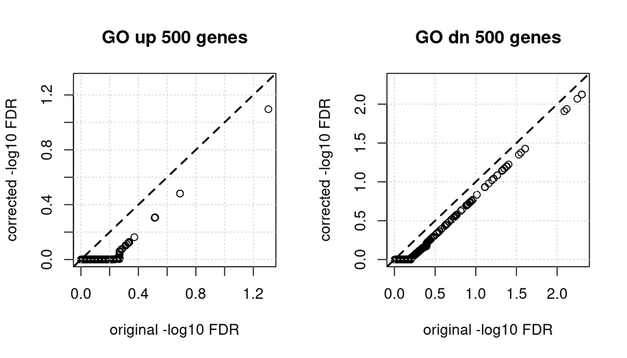

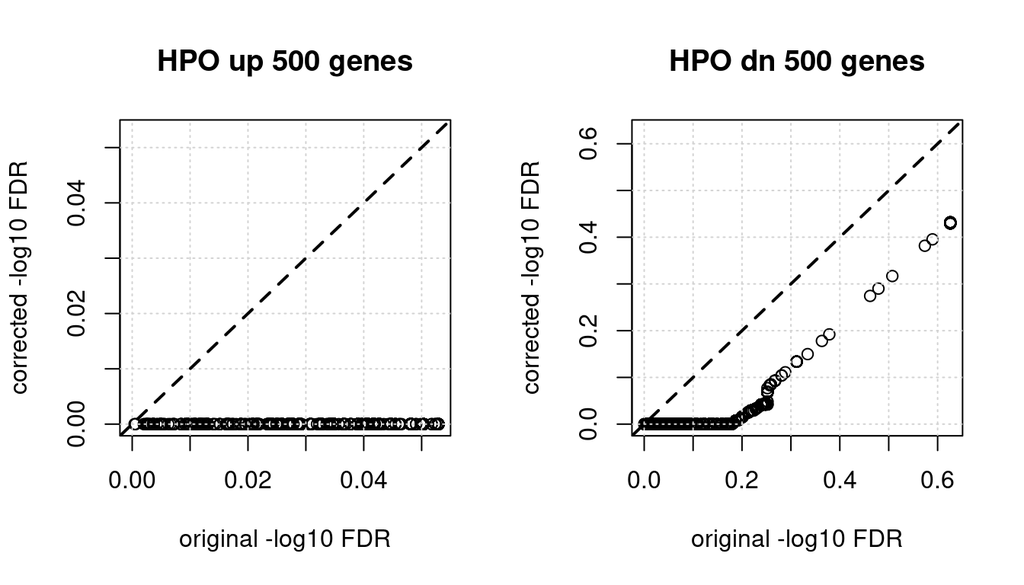

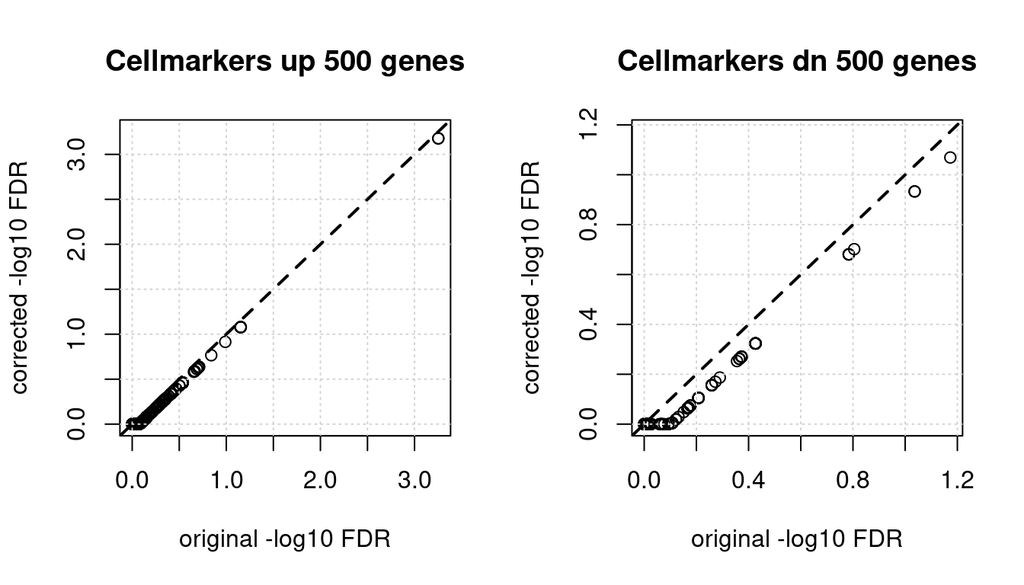

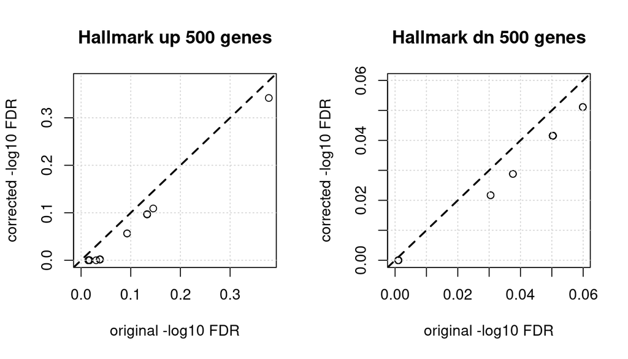

```r
lapply(1:length(gs), function(i) {
  bad <- orabad(d[[1]],gs[[i]],ngenes=500)
  good <- oragood(d[[1]],gs[[i]],ngenes=500)
  compare_ora_plots(bad,good,libname=names(gs)[i],setsize=500)
} )
```